# Part A - 30 Marks - DOMAIN: Medical

# 1. Data Understanding: [5 Marks]

**A. Read all the 3 CSV files as DataFrame and store them into 3 separate variables. [1 Mark]**

```python
import pandas as pd
df = pd.read_csv("D:\Great Learning\Supervised learning\project\Part1Normal.csv")
```

```python
list_of_names = ['Part1Normal','Part1Type_H','Part1Type_S']
dataframes_list = []
for i in range(len(list_of_names)):
    temp_df = pd.read_csv("D:\\Great Learning\\Supervised learning\\project\\"+list_of_names[i] +'.csv')
    dataframes_list.append(temp_df)
temp_df_concat = pd.concat(dataframes_list, axis=0, ignore_index=True)
dataframes_list[0]
temp_df_concat
```

|  | P_incidence | P_tilt | L_angle | S_slope | P_radius | S_Degree | Class |
| --- | --- | --- | --- | --- | --- | --- | --- |
| 0 | 38.505273 | 16.964297 | 35.112814 | 21.540976 | 127.632875 | 7.986683 | Normal |
| 1 | 54.920858 | 18.968430 | 51.601455 | 35.952428 | 125.846646 | 2.001642 | Normal |
| 2 | 44.362490 | 8.945435 | 46.902096 | 35.417055 | 129.220682 | 4.994195 | Normal |
| 3 | 48.318931 | 17.452121 | 48.000000 | 30.866809 | 128.980308 | -0.910941 | Normal |
| 4 | 45.701789 | 10.659859 | 42.577846 | 35.041929 | 130.178314 | -3.388910 | Normal |
| ... | ... | ... | ... | ... | ... | ... | ... |
| 305 | 80.111572 | 33.942432 | 85.101608 | 46.169139 | 125.593624 | 100.292107 | Type_S |
| 306 | 95.480229 | 46.550053 | 59.000000 | 48.930176 | 96.683903 | 77.283072 | Type_S |
| 307 | 74.094731 | 18.823727 | 76.032156 | 55.271004 | 128.405731 | 73.388216 | Type_S |
| 308 | 87.679087 | 20.365613 | 93.822416 | 67.313473 | 120.944829 | 76.730629 | Type_S |
| 309 | 48.259920 | 16.417462 | 36.329137 | 31.842457 | 94.882336 | 28.343799 | Type_S |

310 rows × 7 columns

```python
dataframes_list[0]
```

|  | P_incidence | P_tilt | L_angle | S_slope | P_radius | S_Degree | Class |
| --- | --- | --- | --- | --- | --- | --- | --- |
| 0 | 38.505273 | 16.964297 | 35.112814 | 21.540976 | 127.632875 | 7.986683 | Normal |
| 1 | 54.920858 | 18.968430 | 51.601455 | 35.952428 | 125.846646 | 2.001642 | Normal |
| 2 | 44.362490 | 8.945435 | 46.902096 | 35.417055 | 129.220682 | 4.994195 | Normal |
| 3 | 48.318931 | 17.452121 | 48.000000 | 30.866809 | 128.980308 | -0.910941 | Normal |
| 4 | 45.701789 | 10.659859 | 42.577846 | 35.041929 | 130.178314 | -3.388910 | Normal |
| ... | ... | ... | ... | ... | ... | ... | ... |
| 95 | 47.903565 | 13.616688 | 36.000000 | 34.286877 | 117.449062 | -4.245395 | Normal |
| 96 | 53.936748 | 20.721496 | 29.220534 | 33.215251 | 114.365845 | -0.421010 | Normal |
| 97 | 61.446597 | 22.694968 | 46.170347 | 38.751628 | 125.670725 | -2.707880 | Normal |
| 98 | 45.252792 | 8.693157 | 41.583126 | 36.559635 | 118.545842 | 0.214750 | Normal |
| 99 | 33.841641 | 5.073991 | 36.641233 | 28.767649 | 123.945244 | -0.199249 | Normal |

100 rows × 7 columns

```python
dataframes_list[1]
```

|  | P_incidence | P_tilt | L_angle | S_slope | P_radius | S_Degree | Class |
| --- | --- | --- | --- | --- | --- | --- | --- |
| 0 | 63.027817 | 22.552586 | 39.609117 | 40.475232 | 98.672917 | -0.254400 | Type_H |
| 1 | 39.056951 | 10.060991 | 25.015378 | 28.995960 | 114.405425 | 4.564259 | Type_H |
| 2 | 68.832021 | 22.218482 | 50.092194 | 46.613539 | 105.985135 | -3.530317 | Type_H |
| 3 | 69.297008 | 24.652878 | 44.311238 | 44.644130 | 101.868495 | 11.211523 | Type_H |
| 4 | 49.712859 | 9.652075 | 28.317406 | 40.060784 | 108.168725 | 7.918501 | Type_H |
| 5 | 40.250200 | 13.921907 | 25.124950 | 26.328293 | 130.327871 | 2.230652 | Type_H |
| 6 | 53.432928 | 15.864336 | 37.165934 | 37.568592 | 120.567523 | 5.988551 | Type_H |
| 7 | 45.366754 | 10.755611 | 29.038349 | 34.611142 | 117.270067 | -10.675871 | Type_H |
| 8 | 43.790190 | 13.533753 | 42.690814 | 30.256437 | 125.002893 | 13.289018 | Type_H |
| 9 | 36.686353 | 5.010884 | 41.948751 | 31.675469 | 84.241415 | 0.664437 | Type_H |
| 10 | 49.706610 | 13.040974 | 31.334500 | 36.665635 | 108.648265 | -7.825986 | Type_H |
| 11 | 31.232387 | 17.715819 | 15.500000 | 13.516568 | 120.055399 | 0.499751 | Type_H |
| 12 | 48.915551 | 19.964556 | 40.263794 | 28.950995 | 119.321358 | 8.028895 | Type_H |
| 13 | 53.572170 | 20.460828 | 33.100000 | 33.111342 | 110.966698 | 7.044803 | Type_H |
| 14 | 57.300227 | 24.188885 | 47.000000 | 33.111342 | 116.806587 | 5.766947 | Type_H |
| 15 | 44.318907 | 12.537992 | 36.098763 | 31.780915 | 124.115836 | 5.415825 | Type_H |
| 16 | 63.834982 | 20.362507 | 54.552434 | 43.472475 | 112.309491 | -0.622527 | Type_H |
| 17 | 31.276012 | 3.144669 | 32.562996 | 28.131342 | 129.011418 | 3.623020 | Type_H |
| 18 | 38.697912 | 13.444749 | 31.000000 | 25.253163 | 123.159251 | 1.429186 | Type_H |
| 19 | 41.729963 | 12.254074 | 30.122586 | 29.475889 | 116.585706 | -1.244402 | Type_H |
| 20 | 43.922840 | 14.177959 | 37.832547 | 29.744881 | 134.461016 | 6.451648 | Type_H |
| 21 | 54.919443 | 21.062332 | 42.200000 | 33.857110 | 125.212716 | 2.432561 | Type_H |
| 22 | 63.073611 | 24.413803 | 54.000000 | 38.659808 | 106.424329 | 15.779697 | Type_H |
| 23 | 45.540790 | 13.069598 | 30.298321 | 32.471192 | 117.980830 | -4.987130 | Type_H |
| 24 | 36.125683 | 22.758753 | 29.000000 | 13.366931 | 115.577116 | -3.237562 | Type_H |
| 25 | 54.124920 | 26.650489 | 35.329747 | 27.474432 | 121.447011 | 1.571205 | Type_H |
| 26 | 26.147921 | 10.759454 | 14.000000 | 15.388468 | 125.203296 | -10.093108 | Type_H |
| 27 | 43.580964 | 16.508884 | 47.000000 | 27.072080 | 109.271634 | 8.992816 | Type_H |
| 28 | 44.551012 | 21.931147 | 26.785916 | 22.619865 | 111.072920 | 2.652321 | Type_H |
| 29 | 66.879211 | 24.891999 | 49.278597 | 41.987212 | 113.477018 | -2.005892 | Type_H |
| 30 | 50.819268 | 15.402213 | 42.528939 | 35.417055 | 112.192804 | 10.869566 | Type_H |
| 31 | 46.390260 | 11.079047 | 32.136553 | 35.311213 | 98.774546 | 6.386832 | type_h |
| 32 | 44.936675 | 17.443838 | 27.780576 | 27.492837 | 117.980324 | 5.569620 | type_h |
| 33 | 38.663257 | 12.986441 | 40.000000 | 25.676816 | 124.914118 | 2.703008 | type_h |
| 34 | 59.595540 | 31.998244 | 46.560252 | 27.597296 | 119.330354 | 1.474286 | type_h |
| 35 | 31.484218 | 7.826221 | 24.284818 | 23.657997 | 113.833145 | 4.393080 | type_h |
| 36 | 32.090987 | 6.989378 | 35.998198 | 25.101609 | 132.264735 | 6.413428 | type_h |
| 37 | 35.703458 | 19.443253 | 20.700000 | 16.260205 | 137.540613 | -0.263490 | type_h |
| 38 | 55.843286 | 28.847448 | 47.690543 | 26.995838 | 123.311845 | 2.812427 | type_h |
| 39 | 52.419385 | 19.011561 | 35.872660 | 33.407825 | 116.559771 | 1.694705 | type_h |
| 40 | 35.492446 | 11.701672 | 15.590363 | 23.790774 | 106.938852 | -3.460358 | type_h |
| 41 | 46.442078 | 8.395036 | 29.037230 | 38.047043 | 115.481405 | 2.045476 | type_h |
| 42 | 53.854798 | 19.230643 | 32.779060 | 34.624155 | 121.670915 | 5.329843 | type_h |
| 43 | 66.285394 | 26.327845 | 47.500000 | 39.957549 | 121.219684 | -0.799624 | type_h |
| 44 | 56.030218 | 16.297915 | 62.275275 | 39.732303 | 114.023117 | -2.325684 | type_h |
| 45 | 50.912440 | 23.015169 | 47.000000 | 27.897271 | 117.422259 | -2.526702 | type_h |
| 46 | 48.332638 | 22.227784 | 36.181993 | 26.104854 | 117.384625 | 6.481709 | type_h |
| 47 | 41.352504 | 16.577364 | 30.706191 | 24.775141 | 113.266675 | -4.497958 | type_h |
| 48 | 40.557357 | 17.977784 | 34.000000 | 22.579573 | 121.046246 | -1.537383 | type_h |
| 49 | 41.767732 | 17.899402 | 20.030886 | 23.868330 | 118.363389 | 2.062963 | type_h |
| 50 | 55.285852 | 20.440118 | 34.000000 | 34.845733 | 115.877017 | 3.558372 | type_h |
| 51 | 74.433593 | 41.557331 | 27.700000 | 32.876262 | 107.949304 | 5.000089 | type_h |
| 52 | 50.209670 | 29.760122 | 36.104007 | 20.449548 | 128.292515 | 5.740614 | type_h |
| 53 | 30.149936 | 11.917445 | 34.000000 | 18.232491 | 112.684141 | 11.463223 | type_h |
| 54 | 41.171680 | 17.321206 | 33.469403 | 23.850474 | 116.377889 | -9.569250 | Type_H |
| 55 | 47.657730 | 13.277385 | 36.679985 | 34.380345 | 98.249781 | 6.273012 | Type_H |
| 56 | 43.349606 | 7.467469 | 28.065483 | 35.882137 | 112.776187 | 5.753277 | Type_H |
| 57 | 46.855781 | 15.351514 | 38.000000 | 31.504267 | 116.250917 | 1.662706 | Type_H |
| 58 | 43.203185 | 19.663146 | 35.000000 | 23.540039 | 124.846109 | -2.919076 | Type_H |
| 59 | 48.109236 | 14.930725 | 35.564683 | 33.178512 | 124.056452 | 7.947905 | Type_H |

```python
dataframes_list[2]
```

|  | P_incidence | P_tilt | L_angle | S_slope | P_radius | S_Degree | Class |
| --- | --- | --- | --- | --- | --- | --- | --- |
| 0 | 74.377678 | 32.053104 | 78.772013 | 42.324573 | 143.560690 | 56.125906 | Type_S |
| 1 | 89.680567 | 32.704435 | 83.130732 | 56.976132 | 129.955476 | 92.027277 | Type_S |
| 2 | 44.529051 | 9.433234 | 52.000000 | 35.095817 | 134.711772 | 29.106575 | Type_S |
| 3 | 77.690577 | 21.380645 | 64.429442 | 56.309932 | 114.818751 | 26.931841 | Type_S |
| 4 | 76.147212 | 21.936186 | 82.961502 | 54.211027 | 123.932010 | 10.431972 | Type_S |
| ... | ... | ... | ... | ... | ... | ... | ... |
| 145 | 80.111572 | 33.942432 | 85.101608 | 46.169139 | 125.593624 | 100.292107 | Type_S |
| 146 | 95.480229 | 46.550053 | 59.000000 | 48.930176 | 96.683903 | 77.283072 | Type_S |
| 147 | 74.094731 | 18.823727 | 76.032156 | 55.271004 | 128.405731 | 73.388216 | Type_S |
| 148 | 87.679087 | 20.365613 | 93.822416 | 67.313473 | 120.944829 | 76.730629 | Type_S |
| 149 | 48.259920 | 16.417462 | 36.329137 | 31.842457 | 94.882336 | 28.343799 | Type_S |

150 rows × 7 columns

**#B. Print shape and Column Names and DataTypes of both the Dataframes. [1 Marks]**

```python
shape = dataframes_list[0].shape
shape1=dataframes_list[1].shape
shape2=dataframes_list[2].shape
shape3=temp_df_concat.shape
print('DataFrame[0] Shape :', shape)
print('Number of rows df[0] :', shape[0])
print('Number of columns df[0] :', shape[1])
print('DataFrame[1] Shape :', shape1)
print('Number of rows df[1] :', shape1[0])
print('Number of columns df[1] :', shape1[1])
print('DataFrame[2] Shape :', shape2)
print('Number of rows df[2] :', shape2[0])
print('Number of columns df[2] :', shape2[1])
print('temp_df_concat Shape :', shape3)
print('Number of rows temp_df_concat :', shape3[0])
print('Number of columns temp_df_concat :', shape3[1])
```

```
DataFrame[0] Shape : (100, 7)
Number of rows df[0] : 100
Number of columns df[0] : 7
DataFrame[1] Shape : (60, 7)
Number of rows df[1] : 60
Number of columns df[1] : 7
DataFrame[2] Shape : (150, 7)
Number of rows df[2] : 150
Number of columns df[2] : 7
temp_df_concat Shape : (310, 7)
Number of rows temp_df_concat : 310
Number of columns temp_df_concat : 7
```

**C. Compare Column names of all the 3 DataFrames and clearly write observations. [1 Mark]**

```python
s1=dataframes_list[0].equals(dataframes_list[1])
s2=dataframes_list[0].equals(dataframes_list[2])
s3=dataframes_list[1].equals(dataframes_list[2])
print('df[0] equal to df[1]:', s1,'\ndf[0] equal to df[2]:',s2,'\ndf[2] equal to df[2]:',s3)
```

```
df[0] equal to df[1]: False
df[0] equal to df[2]: False
df[2] equal to df[2]: False
```

```python
#dataframes_list[0].iloc[:,0].equals(dataframes_list[1].iloc[:,0])
a1=(dataframes_list[0].columns.values==dataframes_list[1].columns.values)
a2=(dataframes_list[0].columns.values==dataframes_list[2].columns.values)
a3=(dataframes_list[1].columns.values==dataframes_list[2].columns.values)
print(a1,a2,a3)
```

```
[ True  True  True  True  True  True  True] [ True  True  True  True  True  True  True] [ True  True  True  True  True  True  True]
```

**Observation: The coloumn names and the number of coloumns of all three dataframes are the same but the number of rows are different in all.**

**D. Print DataTypes of all the 3 DataFrames. [1 Mark]**

```python
print("Data Types of The Columns in Data Frame[0]")
display(dataframes_list[0].dtypes)
print("Data Types of The Columns in Data Frame[1]")
display(dataframes_list[1].dtypes)
print("Data Types of The Columns in Data Frame[2]")
display(dataframes_list[2].dtypes)
```

```
Data Types of The Columns in Data Frame[0]
```

```
P_incidence    float64
P_tilt         float64
L_angle        float64
S_slope        float64
P_radius       float64
S_Degree       float64
Class           object
dtype: object
```

```
Data Types of The Columns in Data Frame[1]
```

```
P_incidence    float64
P_tilt         float64
L_angle        float64
S_slope        float64
P_radius       float64
S_Degree       float64
Class           object
dtype: object
```

```
Data Types of The Columns in Data Frame[2]
```

```
P_incidence    float64
P_tilt         float64
L_angle        float64
S_slope        float64
P_radius       float64
S_Degree       float64
Class           object
dtype: object
```

**#E. Observe and share variation in ‘Class’ feature of all the 3 DaraFrames. [1 Mark]**

```python
dataframes_list[0].groupby('Class')
print(dataframes_list[0].groupby('Class').size())
print(dataframes_list[0].groupby('Class').groups)
dataframes_list[1].groupby('Class')
print(dataframes_list[1].groupby('Class').size())
print(dataframes_list[1].groupby('Class').groups)
dataframes_list[2].groupby('Class')
print(dataframes_list[2].groupby('Class').size())
print(dataframes_list[2].groupby('Class').groups)
```

```
Class
Normal    73
Nrmal     27
dtype: int64
{'Normal': [0, 1, 2, 3, 4, 5, 6, 7, 35, 36, 37, 38, 39, 40, 41, 42, 43, 44, 45, 46, 47, 48, 49, 50, 51, 52, 53, 54, 55, 56, 57, 58, 59, 60, 61, 62, 63, 64, 65, 66, 67, 68, 69, 70, 71, 72, 73, 74, 75, 76, 77, 78, 79, 80, 81, 82, 83, 84, 85, 86, 87, 88, 89, 90, 91, 92, 93, 94, 95, 96, 97, 98, 99], 'Nr…
Class
Type_H    37
type_h    23
dtype: int64
{'Type_H': [0, 1, 2, 3, 4, 5, 6, 7, 8, 9, 10, 11, 12, 13, 14, 15, 16, 17, 18, 19, 20, 21, 22, 23, 24, 25, 26, 27, 28, 29, 30, 54, 55, 56, 57, 58, 59], 'type_h': [31, 32, 33, 34, 35, 36, 37, 38, 39, 40, 41, 42, 43, 44, 45, 46, 47, 48, 49, 50, 51, 52, 53]}
Class
Type_S    133
tp_s       17
dtype: int64
{'Type_S': [0, 1, 2, 3, 4, 5, 6, 7, 8, 9, 10, 11, 12, 13, 14, 15, 16, 17, 18, 19, 20, 21, 22, 23, 24, 25, 26, 27, 28, 29, 30, 31, 32, 33, 34, 35, 36, 37, 38, 39, 40, 41, 42, 43, 44, 45, 46, 47, 48, 49, 50, 51, 52, 53, 54, 55, 56, 57, 58, 59, 60, 61, 62, 63, 64, 65, 66, 67, 68, 69, 70, 71, 72, 73, 74…
```

# 2. Data Preparation and Exploration: [5 Marks]

**A. Unify all the variations in ‘Class’ feature for all the 3 DataFrames. [1 Marks]**

```python
dataframes_list[0] = dataframes_list[0].replace("Nrmal", "Normal")
dataframes_list[1]=dataframes_list[1].replace("type_h", "Type_H")
dataframes_list[2]=dataframes_list[2].replace("tp_s", "Type_S")
```

```python
dataframes_list[0]
```

|  | P_incidence | P_tilt | L_angle | S_slope | P_radius | S_Degree | Class |
| --- | --- | --- | --- | --- | --- | --- | --- |
| 0 | 38.505273 | 16.964297 | 35.112814 | 21.540976 | 127.632875 | 7.986683 | Normal |
| 1 | 54.920858 | 18.968430 | 51.601455 | 35.952428 | 125.846646 | 2.001642 | Normal |
| 2 | 44.362490 | 8.945435 | 46.902096 | 35.417055 | 129.220682 | 4.994195 | Normal |
| 3 | 48.318931 | 17.452121 | 48.000000 | 30.866809 | 128.980308 | -0.910941 | Normal |
| 4 | 45.701789 | 10.659859 | 42.577846 | 35.041929 | 130.178314 | -3.388910 | Normal |
| ... | ... | ... | ... | ... | ... | ... | ... |
| 95 | 47.903565 | 13.616688 | 36.000000 | 34.286877 | 117.449062 | -4.245395 | Normal |
| 96 | 53.936748 | 20.721496 | 29.220534 | 33.215251 | 114.365845 | -0.421010 | Normal |
| 97 | 61.446597 | 22.694968 | 46.170347 | 38.751628 | 125.670725 | -2.707880 | Normal |
| 98 | 45.252792 | 8.693157 | 41.583126 | 36.559635 | 118.545842 | 0.214750 | Normal |
| 99 | 33.841641 | 5.073991 | 36.641233 | 28.767649 | 123.945244 | -0.199249 | Normal |

100 rows × 7 columns

```python
dataframes_list[1]
```

|  | P_incidence | P_tilt | L_angle | S_slope | P_radius | S_Degree | Class |
| --- | --- | --- | --- | --- | --- | --- | --- |
| 0 | 63.027817 | 22.552586 | 39.609117 | 40.475232 | 98.672917 | -0.254400 | Type_H |
| 1 | 39.056951 | 10.060991 | 25.015378 | 28.995960 | 114.405425 | 4.564259 | Type_H |
| 2 | 68.832021 | 22.218482 | 50.092194 | 46.613539 | 105.985135 | -3.530317 | Type_H |
| 3 | 69.297008 | 24.652878 | 44.311238 | 44.644130 | 101.868495 | 11.211523 | Type_H |
| 4 | 49.712859 | 9.652075 | 28.317406 | 40.060784 | 108.168725 | 7.918501 | Type_H |
| 5 | 40.250200 | 13.921907 | 25.124950 | 26.328293 | 130.327871 | 2.230652 | Type_H |
| 6 | 53.432928 | 15.864336 | 37.165934 | 37.568592 | 120.567523 | 5.988551 | Type_H |
| 7 | 45.366754 | 10.755611 | 29.038349 | 34.611142 | 117.270067 | -10.675871 | Type_H |
| 8 | 43.790190 | 13.533753 | 42.690814 | 30.256437 | 125.002893 | 13.289018 | Type_H |
| 9 | 36.686353 | 5.010884 | 41.948751 | 31.675469 | 84.241415 | 0.664437 | Type_H |
| 10 | 49.706610 | 13.040974 | 31.334500 | 36.665635 | 108.648265 | -7.825986 | Type_H |
| 11 | 31.232387 | 17.715819 | 15.500000 | 13.516568 | 120.055399 | 0.499751 | Type_H |
| 12 | 48.915551 | 19.964556 | 40.263794 | 28.950995 | 119.321358 | 8.028895 | Type_H |
| 13 | 53.572170 | 20.460828 | 33.100000 | 33.111342 | 110.966698 | 7.044803 | Type_H |
| 14 | 57.300227 | 24.188885 | 47.000000 | 33.111342 | 116.806587 | 5.766947 | Type_H |
| 15 | 44.318907 | 12.537992 | 36.098763 | 31.780915 | 124.115836 | 5.415825 | Type_H |
| 16 | 63.834982 | 20.362507 | 54.552434 | 43.472475 | 112.309491 | -0.622527 | Type_H |
| 17 | 31.276012 | 3.144669 | 32.562996 | 28.131342 | 129.011418 | 3.623020 | Type_H |
| 18 | 38.697912 | 13.444749 | 31.000000 | 25.253163 | 123.159251 | 1.429186 | Type_H |
| 19 | 41.729963 | 12.254074 | 30.122586 | 29.475889 | 116.585706 | -1.244402 | Type_H |
| 20 | 43.922840 | 14.177959 | 37.832547 | 29.744881 | 134.461016 | 6.451648 | Type_H |
| 21 | 54.919443 | 21.062332 | 42.200000 | 33.857110 | 125.212716 | 2.432561 | Type_H |
| 22 | 63.073611 | 24.413803 | 54.000000 | 38.659808 | 106.424329 | 15.779697 | Type_H |
| 23 | 45.540790 | 13.069598 | 30.298321 | 32.471192 | 117.980830 | -4.987130 | Type_H |
| 24 | 36.125683 | 22.758753 | 29.000000 | 13.366931 | 115.577116 | -3.237562 | Type_H |
| 25 | 54.124920 | 26.650489 | 35.329747 | 27.474432 | 121.447011 | 1.571205 | Type_H |
| 26 | 26.147921 | 10.759454 | 14.000000 | 15.388468 | 125.203296 | -10.093108 | Type_H |
| 27 | 43.580964 | 16.508884 | 47.000000 | 27.072080 | 109.271634 | 8.992816 | Type_H |
| 28 | 44.551012 | 21.931147 | 26.785916 | 22.619865 | 111.072920 | 2.652321 | Type_H |
| 29 | 66.879211 | 24.891999 | 49.278597 | 41.987212 | 113.477018 | -2.005892 | Type_H |
| 30 | 50.819268 | 15.402213 | 42.528939 | 35.417055 | 112.192804 | 10.869566 | Type_H |
| 31 | 46.390260 | 11.079047 | 32.136553 | 35.311213 | 98.774546 | 6.386832 | Type_H |
| 32 | 44.936675 | 17.443838 | 27.780576 | 27.492837 | 117.980324 | 5.569620 | Type_H |
| 33 | 38.663257 | 12.986441 | 40.000000 | 25.676816 | 124.914118 | 2.703008 | Type_H |
| 34 | 59.595540 | 31.998244 | 46.560252 | 27.597296 | 119.330354 | 1.474286 | Type_H |
| 35 | 31.484218 | 7.826221 | 24.284818 | 23.657997 | 113.833145 | 4.393080 | Type_H |
| 36 | 32.090987 | 6.989378 | 35.998198 | 25.101609 | 132.264735 | 6.413428 | Type_H |
| 37 | 35.703458 | 19.443253 | 20.700000 | 16.260205 | 137.540613 | -0.263490 | Type_H |
| 38 | 55.843286 | 28.847448 | 47.690543 | 26.995838 | 123.311845 | 2.812427 | Type_H |
| 39 | 52.419385 | 19.011561 | 35.872660 | 33.407825 | 116.559771 | 1.694705 | Type_H |
| 40 | 35.492446 | 11.701672 | 15.590363 | 23.790774 | 106.938852 | -3.460358 | Type_H |
| 41 | 46.442078 | 8.395036 | 29.037230 | 38.047043 | 115.481405 | 2.045476 | Type_H |
| 42 | 53.854798 | 19.230643 | 32.779060 | 34.624155 | 121.670915 | 5.329843 | Type_H |
| 43 | 66.285394 | 26.327845 | 47.500000 | 39.957549 | 121.219684 | -0.799624 | Type_H |
| 44 | 56.030218 | 16.297915 | 62.275275 | 39.732303 | 114.023117 | -2.325684 | Type_H |
| 45 | 50.912440 | 23.015169 | 47.000000 | 27.897271 | 117.422259 | -2.526702 | Type_H |
| 46 | 48.332638 | 22.227784 | 36.181993 | 26.104854 | 117.384625 | 6.481709 | Type_H |
| 47 | 41.352504 | 16.577364 | 30.706191 | 24.775141 | 113.266675 | -4.497958 | Type_H |
| 48 | 40.557357 | 17.977784 | 34.000000 | 22.579573 | 121.046246 | -1.537383 | Type_H |
| 49 | 41.767732 | 17.899402 | 20.030886 | 23.868330 | 118.363389 | 2.062963 | Type_H |
| 50 | 55.285852 | 20.440118 | 34.000000 | 34.845733 | 115.877017 | 3.558372 | Type_H |
| 51 | 74.433593 | 41.557331 | 27.700000 | 32.876262 | 107.949304 | 5.000089 | Type_H |
| 52 | 50.209670 | 29.760122 | 36.104007 | 20.449548 | 128.292515 | 5.740614 | Type_H |
| 53 | 30.149936 | 11.917445 | 34.000000 | 18.232491 | 112.684141 | 11.463223 | Type_H |
| 54 | 41.171680 | 17.321206 | 33.469403 | 23.850474 | 116.377889 | -9.569250 | Type_H |
| 55 | 47.657730 | 13.277385 | 36.679985 | 34.380345 | 98.249781 | 6.273012 | Type_H |
| 56 | 43.349606 | 7.467469 | 28.065483 | 35.882137 | 112.776187 | 5.753277 | Type_H |
| 57 | 46.855781 | 15.351514 | 38.000000 | 31.504267 | 116.250917 | 1.662706 | Type_H |
| 58 | 43.203185 | 19.663146 | 35.000000 | 23.540039 | 124.846109 | -2.919076 | Type_H |
| 59 | 48.109236 | 14.930725 | 35.564683 | 33.178512 | 124.056452 | 7.947905 | Type_H |

```python
dataframes_list[2]
```

|  | P_incidence | P_tilt | L_angle | S_slope | P_radius | S_Degree | Class |
| --- | --- | --- | --- | --- | --- | --- | --- |
| 0 | 74.377678 | 32.053104 | 78.772013 | 42.324573 | 143.560690 | 56.125906 | Type_S |
| 1 | 89.680567 | 32.704435 | 83.130732 | 56.976132 | 129.955476 | 92.027277 | Type_S |
| 2 | 44.529051 | 9.433234 | 52.000000 | 35.095817 | 134.711772 | 29.106575 | Type_S |
| 3 | 77.690577 | 21.380645 | 64.429442 | 56.309932 | 114.818751 | 26.931841 | Type_S |
| 4 | 76.147212 | 21.936186 | 82.961502 | 54.211027 | 123.932010 | 10.431972 | Type_S |
| ... | ... | ... | ... | ... | ... | ... | ... |
| 145 | 80.111572 | 33.942432 | 85.101608 | 46.169139 | 125.593624 | 100.292107 | Type_S |
| 146 | 95.480229 | 46.550053 | 59.000000 | 48.930176 | 96.683903 | 77.283072 | Type_S |
| 147 | 74.094731 | 18.823727 | 76.032156 | 55.271004 | 128.405731 | 73.388216 | Type_S |
| 148 | 87.679087 | 20.365613 | 93.822416 | 67.313473 | 120.944829 | 76.730629 | Type_S |
| 149 | 48.259920 | 16.417462 | 36.329137 | 31.842457 | 94.882336 | 28.343799 | Type_S |

150 rows × 7 columns

**#B. Combine all the 3 DataFrames to form a single DataFrame [1 Marks]**

```python
dff=pd.concat([dataframes_list[0], dataframes_list[1],dataframes_list[2]])
dff = dff.reset_index()
dff
```

|  | index | P_incidence | P_tilt | L_angle | S_slope | P_radius | S_Degree | Class |
| --- | --- | --- | --- | --- | --- | --- | --- | --- |
| 0 | 0 | 38.505273 | 16.964297 | 35.112814 | 21.540976 | 127.632875 | 7.986683 | Normal |
| 1 | 1 | 54.920858 | 18.968430 | 51.601455 | 35.952428 | 125.846646 | 2.001642 | Normal |
| 2 | 2 | 44.362490 | 8.945435 | 46.902096 | 35.417055 | 129.220682 | 4.994195 | Normal |
| 3 | 3 | 48.318931 | 17.452121 | 48.000000 | 30.866809 | 128.980308 | -0.910941 | Normal |
| 4 | 4 | 45.701789 | 10.659859 | 42.577846 | 35.041929 | 130.178314 | -3.388910 | Normal |
| ... | ... | ... | ... | ... | ... | ... | ... | ... |
| 305 | 145 | 80.111572 | 33.942432 | 85.101608 | 46.169139 | 125.593624 | 100.292107 | Type_S |
| 306 | 146 | 95.480229 | 46.550053 | 59.000000 | 48.930176 | 96.683903 | 77.283072 | Type_S |
| 307 | 147 | 74.094731 | 18.823727 | 76.032156 | 55.271004 | 128.405731 | 73.388216 | Type_S |
| 308 | 148 | 87.679087 | 20.365613 | 93.822416 | 67.313473 | 120.944829 | 76.730629 | Type_S |
| 309 | 149 | 48.259920 | 16.417462 | 36.329137 | 31.842457 | 94.882336 | 28.343799 | Type_S |

310 rows × 8 columns

**#C. Print 5 random samples of this DataFrame [1 Marks]**

```python
dff.sample(n = 5)
```

|  | index | P_incidence | P_tilt | L_angle | S_slope | P_radius | S_Degree | Class |
| --- | --- | --- | --- | --- | --- | --- | --- | --- |
| 223 | 63 | 65.665347 | 10.540675 | 56.489135 | 55.124672 | 109.162777 | 53.932020 | Type_S |
| 41 | 41 | 40.746996 | 1.835524 | 50.000000 | 38.911472 | 139.247150 | 0.668557 | Normal |
| 95 | 95 | 47.903565 | 13.616688 | 36.000000 | 34.286877 | 117.449062 | -4.245395 | Normal |
| 88 | 88 | 66.507179 | 20.897672 | 31.727471 | 45.609507 | 128.902905 | 1.517203 | Normal |
| 289 | 129 | 82.406524 | 29.276422 | 77.054565 | 53.130102 | 117.042244 | 62.765348 | Type_S |

**#D. Print Feature-wise percentage of Null values. [1 Mark]**

```python
dff.isnull().sum()
```

```
index          0
P_incidence    0
P_tilt         0
L_angle        0
S_slope        0
P_radius       0
S_Degree       0
Class          0
dtype: int64
```

**#E. Check 5-point summary of the new DataFrame. [1 Mark]**

```python
dff.info()
```

```
<class 'pandas.core.frame.DataFrame'>
RangeIndex: 310 entries, 0 to 309
Data columns (total 8 columns):
 #   Column       Non-Null Count  Dtype
---  ------       --------------  -----
 0   index        310 non-null    int64
 1   P_incidence  310 non-null    float64
 2   P_tilt       310 non-null    float64
 3   L_angle      310 non-null    float64
 4   S_slope      310 non-null    float64
 5   P_radius     310 non-null    float64
 6   S_Degree     310 non-null    float64
 7   Class        310 non-null    object
dtypes: float64(6), int64(1), object(1)
memory usage: 19.5+ KB
```

```python
from numpy import percentile
quart = dff.quantile(q=[.25, .50, .75])
dff_min, dff_max = dff.min(), dff.max()
quart,dff_min, dff_max
```

```
(      index  P_incidence     P_tilt    L_angle    S_slope    P_radius  \
 0.25  25.25    46.430294  10.667069  37.000000  33.347122  110.709196
 0.50  51.00    58.691038  16.357689  49.562398  42.404912  118.268178
 0.75  85.75    72.877696  22.120395  63.000000  52.695888  125.467674

        S_Degree
 0.25   1.603727
 0.50  11.767934
 0.75  41.287352  ,
 index                  0
 P_incidence    26.147921
 P_tilt         -6.554948
 L_angle             14.0
 S_slope        13.366931
 P_radius       70.082575
 S_Degree      -11.058179
 Class             Normal
 dtype: object,
 index                 149
 P_incidence    129.834041
 P_tilt          49.431864
 L_angle        125.742385
 S_slope        121.429566
 P_radius       163.071041
 S_Degree       418.543082
 Class              Type_S
 dtype: object)
```

```python
print(dff.Class)
```

```
0      Normal
1      Normal
2      Normal
3      Normal
4      Normal
        ...
305    Type_S
306    Type_S
307    Type_S
308    Type_S
309    Type_S
Name: Class, Length: 310, dtype: object
```

# 3. Data Analysis: [10 Marks]

**#A. Visualize a heatmap to understand correlation between all features [2 Marks]**

```python
corr1=dff.corr()
print(corr1)
```

```
                index  P_incidence    P_tilt   L_angle   S_slope  P_radius  \
index        1.000000     0.253943  0.088791  0.333948  0.259884 -0.245724
P_incidence  0.253943     1.000000  0.629199  0.717282  0.814960 -0.247467
P_tilt       0.088791     0.629199  1.000000  0.432764  0.062345  0.032668
L_angle      0.333948     0.717282  0.432764  1.000000  0.598387 -0.080344
S_slope      0.259884     0.814960  0.062345  0.598387  1.000000 -0.342128
P_radius    -0.245724    -0.247467  0.032668 -0.080344 -0.342128  1.000000
S_Degree     0.260775     0.638743  0.397862  0.533667  0.523557 -0.026065

             S_Degree
index        0.260775
P_incidence  0.638743
P_tilt       0.397862
L_angle      0.533667
S_slope      0.523557
P_radius    -0.026065
S_Degree     1.000000
```

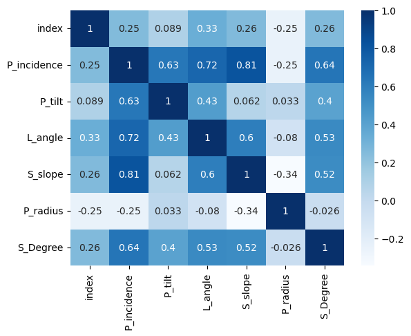

```python
import pandas as pd
import matplotlib.pyplot as plt
import seaborn as sb
#corr = df.corr()
sb.heatmap(corr1, cmap="Blues", annot=True)
#columns=['P_incidence','P_tilt','L_angle','S_slope','P_radius','S_Degree']
#plt.xticks(range(len(columns)),columns,rotation=90)
#plt.yticks(range(len(columns)),columns)
#plt.imshow(corr1, cmap='hot',interpolation="nearest",annot=True)
```

#B. Share insights on correlation. [2 Marks]  
A. Features having stronger correlation with correlation value.  
B. Features having weaker correlation with correlation value

**#C. Visualize a pairplot with 3 classes distinguished by colors and share insights. [2 Marks]**

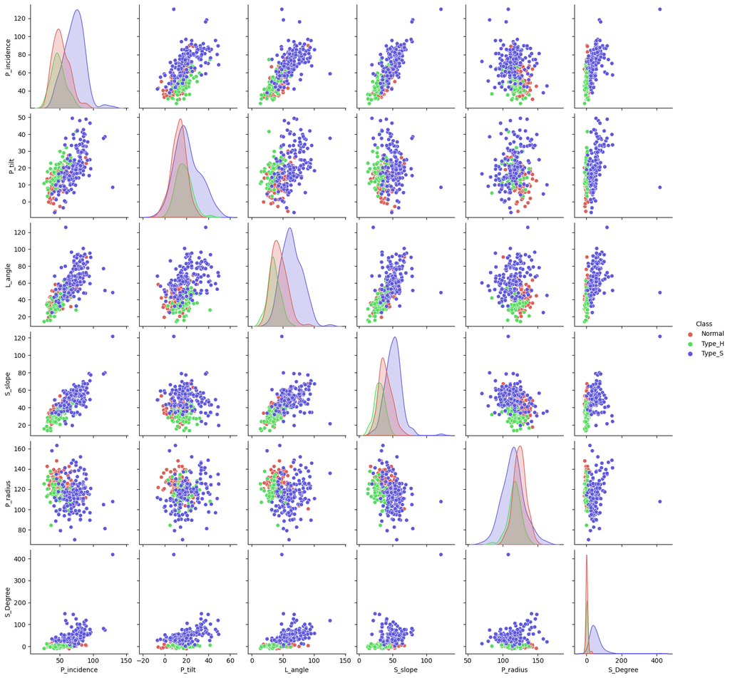

```python
#df = sb.load_dataset('dff')
#df = dff[~dff.index.duplicated()]
cols_to_plot=dff.columns[1:7].tolist() + ['Class']
sb.pairplot(dff[cols_to_plot],hue="Class", palette='hls')
plt.show()
```

*Pairplot also shows that P_incidence has strong correlation with S_slope parameter and P_incidence and P_radius have weak correlation*

**#D. Visualize a jointplot for ‘P_incidence’ and ‘S_slope’ and share insights. [2 Marks]**

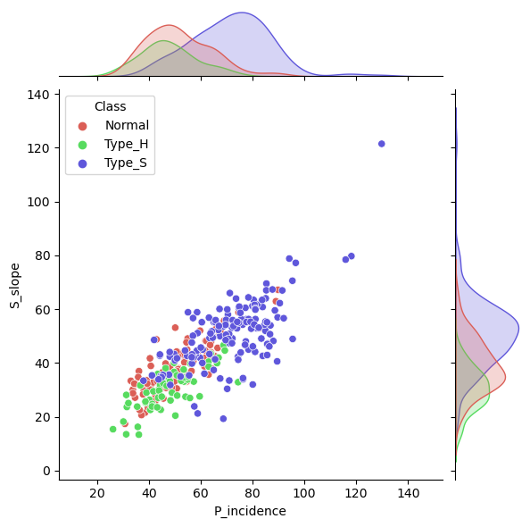

```python
sb.jointplot(data=dff, x="P_incidence", y="S_slope",hue="Class",palette='hls')
```

*Inference: P_incidence is right skewed wrt to S_slope in Class Type_S compared to Class Normal and Class Type_H*

**#E. Visualize a boxplot to check distribution of the features and share insights. [2 Marks]**

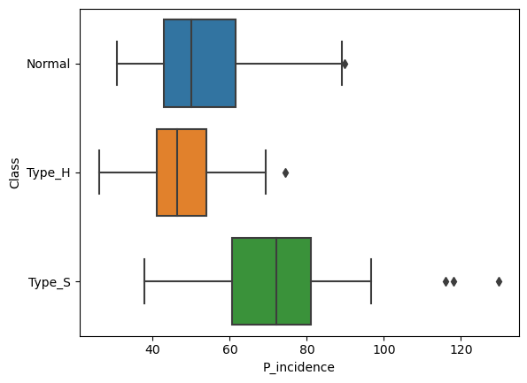

```python
box1=sb.boxplot(data=dff, x="P_incidence",y="Class")
```

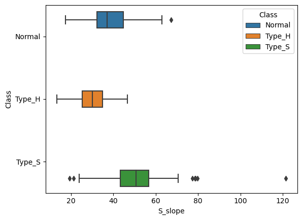

```python
box2=sb.boxplot(data=dff, x="S_slope", y='Class',hue="Class")
```

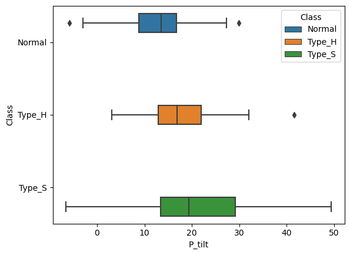

```python
box3=sb.boxplot(data=dff, x="P_tilt", y='Class',hue="Class")
```

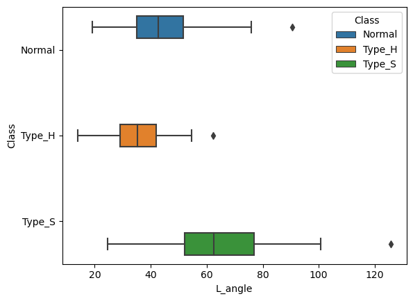

```python
box4=sb.boxplot(data=dff, x="L_angle", y='Class',hue="Class")
```

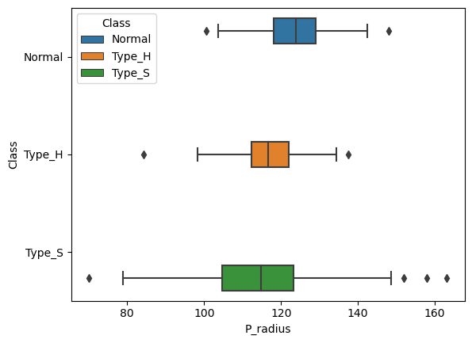

```python
box5=sb.boxplot(data=dff, x="P_radius", y='Class',hue="Class")
```

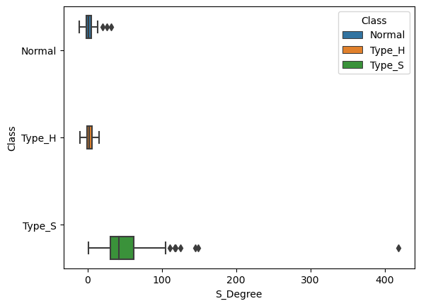

```python
box6=sb.boxplot(data=dff, x="S_Degree", y='Class',hue="Class")
```

# 4. Model Building: [6 Marks]

**#A. Split data into X and Y. [1 Marks]**

```python
dff["Class"].value_counts(normalize=True)
```

```
Type_S    0.483871
Normal    0.322581
Type_H    0.193548
Name: Class, dtype: float64
```

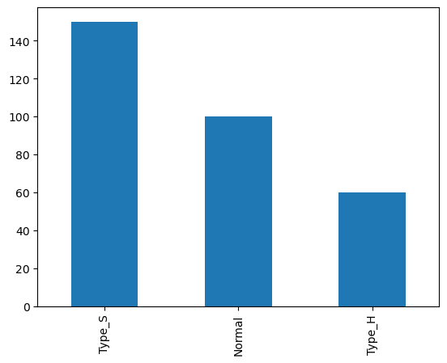

```python
pd.value_counts(dff["Class"]).plot(kind="bar")
```

```python
#Use label encoder to convert categorical variables to one-hot encoding (dummy variables)
from sklearn.preprocessing import LabelEncoder
le = LabelEncoder()
dff['Class'] = le.fit_transform(dff['Class'])
```

```python
X = dff.iloc[:,:-1]
X
```

|  | index | P_incidence | P_tilt | L_angle | S_slope | P_radius | S_Degree |
| --- | --- | --- | --- | --- | --- | --- | --- |
| 0 | 0 | 38.505273 | 16.964297 | 35.112814 | 21.540976 | 127.632875 | 7.986683 |
| 1 | 1 | 54.920858 | 18.968430 | 51.601455 | 35.952428 | 125.846646 | 2.001642 |
| 2 | 2 | 44.362490 | 8.945435 | 46.902096 | 35.417055 | 129.220682 | 4.994195 |
| 3 | 3 | 48.318931 | 17.452121 | 48.000000 | 30.866809 | 128.980308 | -0.910941 |
| 4 | 4 | 45.701789 | 10.659859 | 42.577846 | 35.041929 | 130.178314 | -3.388910 |
| ... | ... | ... | ... | ... | ... | ... | ... |
| 305 | 145 | 80.111572 | 33.942432 | 85.101608 | 46.169139 | 125.593624 | 100.292107 |
| 306 | 146 | 95.480229 | 46.550053 | 59.000000 | 48.930176 | 96.683903 | 77.283072 |
| 307 | 147 | 74.094731 | 18.823727 | 76.032156 | 55.271004 | 128.405731 | 73.388216 |
| 308 | 148 | 87.679087 | 20.365613 | 93.822416 | 67.313473 | 120.944829 | 76.730629 |
| 309 | 149 | 48.259920 | 16.417462 | 36.329137 | 31.842457 | 94.882336 | 28.343799 |

310 rows × 7 columns

```python
Y = dff.iloc[:,-1]
Y
```

```
0      0
1      0
2      0
3      0
4      0
      ..
305    2
306    2
307    2
308    2
309    2
Name: Class, Length: 310, dtype: int32
```

**#B. Split data into train and test with 80:20 proportion. [1 Marks]**

```python
from sklearn.model_selection import train_test_split
x_train, x_test, y_train, y_test= train_test_split(X, Y, test_size= 0.2, random_state=0)
x_train
```

|  | index | P_incidence | P_tilt | L_angle | S_slope | P_radius | S_Degree |
| --- | --- | --- | --- | --- | --- | --- | --- |
| 21 | 21 | 53.911054 | 12.939318 | 39.000000 | 40.971736 | 118.193035 | 5.074353 |
| 101 | 1 | 39.056951 | 10.060991 | 25.015378 | 28.995960 | 114.405425 | 4.564259 |
| 235 | 75 | 77.121344 | 30.349874 | 77.481083 | 46.771470 | 110.611148 | 82.093607 |
| 45 | 45 | 67.538182 | 14.655042 | 58.001429 | 52.883139 | 123.632260 | 25.970206 |
| 89 | 89 | 82.905351 | 29.894119 | 58.250542 | 53.011232 | 110.708958 | 6.079338 |
| ... | ... | ... | ... | ... | ... | ... | ... |
| 251 | 91 | 48.030624 | 3.969815 | 58.344519 | 44.060809 | 125.350962 | 35.000078 |
| 192 | 32 | 85.352315 | 15.844910 | 71.668660 | 69.507405 | 124.419787 | 76.020603 |
| 117 | 17 | 31.276012 | 3.144669 | 32.562996 | 28.131342 | 129.011418 | 3.623020 |
| 47 | 47 | 50.160078 | -2.970024 | 42.000000 | 53.130102 | 131.802491 | -8.290203 |
| 172 | 12 | 84.974132 | 33.021175 | 60.859873 | 51.952957 | 125.659534 | 74.333409 |

248 rows × 7 columns

```python
x_test
```

|  | index | P_incidence | P_tilt | L_angle | S_slope | P_radius | S_Degree |
| --- | --- | --- | --- | --- | --- | --- | --- |
| 300 | 140 | 63.364339 | 20.024621 | 67.498705 | 43.339718 | 130.999258 | 37.556706 |
| 145 | 45 | 50.912440 | 23.015169 | 47.000000 | 27.897271 | 117.422259 | -2.526702 |
| 302 | 142 | 76.314028 | 41.933683 | 93.284863 | 34.380345 | 132.267286 | 101.218783 |
| 222 | 62 | 80.074914 | 48.069531 | 52.403439 | 32.005383 | 110.709912 | 67.727316 |
| 52 | 52 | 42.517272 | 14.375671 | 25.323565 | 28.141601 | 128.905689 | 0.757020 |
| ... | ... | ... | ... | ... | ... | ... | ... |
| 200 | 40 | 84.585607 | 30.361685 | 65.479486 | 54.223922 | 108.010218 | 25.118478 |
| 59 | 59 | 37.140150 | 16.481240 | 24.000000 | 20.658910 | 125.014361 | 7.366425 |
| 34 | 34 | 63.026300 | 27.336240 | 51.605017 | 35.690060 | 114.506608 | 7.439870 |
| 269 | 109 | 44.253476 | 1.101087 | 38.000000 | 43.152390 | 98.274107 | 23.910635 |
| 33 | 33 | 34.649922 | 7.514783 | 43.000000 | 27.135140 | 123.987741 | -4.082938 |

62 rows × 7 columns

```python
y_train
```

```
21     0
101    1
235    2
45     0
89     0
      ..
251    2
192    2
117    1
47     0
172    2
Name: Class, Length: 248, dtype: int32
```

```python
y_test
```

```
300    2
145    1
302    2
222    2
52     0
      ..
200    2
59     0
34     0
269    2
33     0
Name: Class, Length: 62, dtype: int32
```

**#C. Train a Supervised Learning Classification base model using KNN classifier. [2 Marks]**

```python
from sklearn.neighbors import KNeighborsClassifier
from sklearn.metrics import accuracy_score
from sklearn.metrics import recall_score
from sklearn.metrics import precision_score
from sklearn.metrics import classification_report
from sklearn.metrics import confusion_matrix
print(confusion_matrix(y_test, y_pred))


# instantiate learning model (k = 3)
knn = KNeighborsClassifier(n_neighbors = 3)

# fitting the model
knn.fit(x_train, y_train)

# predict the response
y_pred = knn.predict(x_test)
print(y_pred)
# evaluate accuracy
```

[output not shown]

**#D. Print all the possible performance metrics for both train and test data. [2 Marks]**

```python
print("Accuracy Score(k=3) :",accuracy_score(y_test, y_pred))
print("Precision Score(k=3) : ",precision_score(y_test, y_pred,pos_label='positive',average='micro'))
print("Recall Score(k=3) : ",recall_score(y_test, y_pred, pos_label='positive',average='micro'))
```

```
Accuracy Score(k=3) : 0.8064516129032258
Precision Score(k=3) :  0.8064516129032258
Recall Score(k=3) :  0.8064516129032258
```

# 5. Performance Improvement: [4 Marks]

**A. Experiment with various parameters to improve performance of the base model. [2 Marks]**

```python
knn_score = knn.score(x_test, y_test)
print(f"Score : {knn_score}")
```

[output not shown]

```python
#Logistic Regression
from sklearn.linear_model import LogisticRegression
logreg = LogisticRegression(solver = 'liblinear', multi_class= 'auto')
logreg.fit(x_train, y_train)
lr_score = logreg.score(x_test, y_test)
print(f"Score : {lr_score}")
```

```
Score : 0.8387096774193549
```

```python
from sklearn.naive_bayes import GaussianNB
nb = GaussianNB()
nb.fit(x_train, y_train)
nb_score = nb.score(x_test, y_test)
print(f"Score : {nb_score}")
```

```
Score : 0.8225806451612904
```

```python
pd.DataFrame({'Accuracy' : [knn_score,lr_score,nb_score]}, index = ['k-NN','Logistic Regression',  'Naive Bayes'] )
```

|  | Accuracy |
| --- | --- |
| k-NN | 0.822581 |
| Logistic Regression | 0.838710 |
| Naive Bayes | 0.822581 |

*Logistic regression has performed the best of all the models. But k_NN and Naive Bayes score are almost close to Logistic regression model*

```python
# instantiate learning model (k = 5)
knn = KNeighborsClassifier(n_neighbors=5)

# fitting the model
knn.fit(x_train, y_train)

# predict the response
y_pred = knn.predict(x_test)

# evaluate accuracy
print("Accuracy Score(k=5) :",accuracy_score(y_test, y_pred))
print("Precision Score(k=5) : ",precision_score(y_test, y_pred,pos_label='positive',average='micro'))
print("Recall Score(k=5) : ",recall_score(y_test, y_pred, pos_label='positive',average='micro'))
# instantiate learning model (k = 9)
knn = KNeighborsClassifier(n_neighbors=9)

# fitting the model
knn.fit(x_train, y_train)

# predict the response
y_pred = knn.predict(x_test)

# evaluate accuracy
print("Accuracy Score(k=9) :" ,accuracy_score(y_test, y_pred))
print("Precision Score(k=9) : ",precision_score(y_test, y_pred,pos_label='positive',average='micro'))
print("Recall Score(k=9) : ",recall_score(y_test, y_pred, pos_label='positive',average='micro'))
```

```
Accuracy Score(k=5) : 0.8225806451612904
Precision Score(k=5) :  0.8225806451612904
Recall Score(k=5) :  0.8225806451612904
Accuracy Score(k=9) : 0.8387096774193549
Precision Score(k=9) :  0.8387096774193549
Recall Score(k=9) :  0.8387096774193549
```

**#B. Clearly showcase improvement in performance achieved. [1 Marks]**

```python
# creating odd list of K for KNN
myList = list(range(1,20))

# subsetting just the odd ones
neighbors = list(filter(lambda x: x % 2 != 0, myList))
```

```python
# empty list that will hold accuracy scores
ac_scores = []
re_scores = []
pr_scores=[]

# perform accuracy metrics for values from 1,3,5....19
for k in neighbors:
    knn = KNeighborsClassifier(n_neighbors=k)
    knn.fit(x_train, y_train)
    # predict the response
    y_pred = knn.predict(x_test)
    # evaluate accuracy
    scores = accuracy_score(y_test, y_pred)
    scores1 = recall_score(y_test, y_pred,pos_label='positive',average='micro')
    scores2=precision_score(y_test, y_pred,pos_label='positive',average='micro')
    ac_scores.append(scores)
    re_scores.append(scores1)
    pr_scores.append(scores2)
# changing to misclassification error
MSE = [1 - x for x in ac_scores]

# determining best k
optimal_k = neighbors[MSE.index(min(MSE))]
print("The optimal number of neighbors is %d" % optimal_k)
print("The recall scores range for different k:\n",  re_scores)
print("The accuracy scores range for different k:\n", ac_scores)
print("The precision scores range for different k:\n", pr_scores)
```

```
The optimal number of neighbors is 13
The recall scores range for different k:
 [0.7741935483870968, 0.8064516129032258, 0.8225806451612904, 0.8225806451612904, 0.8387096774193549, 0.8225806451612904, 0.8548387096774194, 0.8548387096774194, 0.8548387096774194, 0.8225806451612904]
The accuracy scores range for different k:
 [0.7741935483870968, 0.8064516129032258, 0.8225806451612904, 0.8225806451612904, 0.8387096774193549, 0.8225806451612904, 0.8548387096774194, 0.8548387096774194, 0.8548387096774194, 0.8225806451612904]
The precision scores range for different k:
 [0.7741935483870968, 0.8064516129032258, 0.8225806451612904, 0.8225806451612904, 0.8387096774193549, 0.8225806451612904, 0.8548387096774194, 0.8548387096774194, 0.8548387096774194, 0.8225806451612904]
```

[output not shown]

[output cut: 34 more lines]

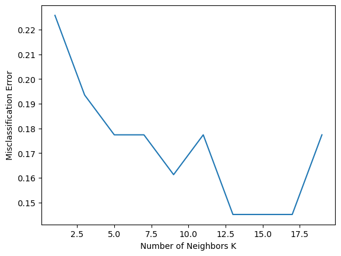

```python
import matplotlib.pyplot as plt
# plot misclassification error vs k
plt.plot(neighbors, MSE)
plt.xlabel('Number of Neighbors K')
plt.ylabel('Misclassification Error')
plt.show()
```

**#C. Clearly state which parameters contributed most to improve model performance. [1 Marks]**

```python
#Use k=3 as the final model for prediction
knn = KNeighborsClassifier(n_neighbors = 13)

# fitting the model
knn.fit(x_train, y_train)

# predict the response
y_pred = knn.predict(x_test)

# evaluate accuracy
print("Accuracy score(k=13):",accuracy_score(y_test, y_pred))
print("Recall Score(k=13): ",recall_score(y_test, y_pred,pos_label='positive',average='micro'))
print("Precision Score(k=13): ",precision_score(y_test, y_pred,pos_label='positive',average='micro'))
```

```
Accuracy score(k=13): 0.8548387096774194
Recall Score(k=13):  0.8548387096774194
Precision Score(k=13):  0.8548387096774194
```

*Changing K value to K=13 improved the accoracy by 5%. Before optimization of K accuracy was 80% for K=3 and after optimization of K=13 the accuracy increased to 85%*

*The final model has a good accuracy as well as recall and precision score*

# Part B - 30 Marks ; DOMAIN: Banking, Marketing

# 1. Data Understanding and Preparation: [5 Marks]

**A. Read both the Datasets ‘Data1’ and ‘Data 2’ as DataFrame and store them into two separate variables. [1 Marks]**

```python
import pandas as pd
df1 = pd.read_csv("D:\Great Learning\Supervised learning\project\Part2Data1.csv")
df2 = pd.read_csv("D:\Great Learning\Supervised learning\project\Part2Data2.csv")
df1
```

|  | ID | Age | CustomerSince | HighestSpend | ZipCode | HiddenScore | MonthlyAverageSpend | Level |
| --- | --- | --- | --- | --- | --- | --- | --- | --- |
| 0 | 1 | 25 | 1 | 49 | 91107 | 4 | 1.6 | 1 |
| 1 | 2 | 45 | 19 | 34 | 90089 | 3 | 1.5 | 1 |
| 2 | 3 | 39 | 15 | 11 | 94720 | 1 | 1.0 | 1 |
| 3 | 4 | 35 | 9 | 100 | 94112 | 1 | 2.7 | 2 |
| 4 | 5 | 35 | 8 | 45 | 91330 | 4 | 1.0 | 2 |
| ... | ... | ... | ... | ... | ... | ... | ... | ... |
| 4995 | 4996 | 29 | 3 | 40 | 92697 | 1 | 1.9 | 3 |
| 4996 | 4997 | 30 | 4 | 15 | 92037 | 4 | 0.4 | 1 |
| 4997 | 4998 | 63 | 39 | 24 | 93023 | 2 | 0.3 | 3 |
| 4998 | 4999 | 65 | 40 | 49 | 90034 | 3 | 0.5 | 2 |
| 4999 | 5000 | 28 | 4 | 83 | 92612 | 3 | 0.8 | 1 |

5000 rows × 8 columns

```python
df2
```

|  | ID | Mortgage | Security | FixedDepositAccount | InternetBanking | CreditCard | LoanOnCard |
| --- | --- | --- | --- | --- | --- | --- | --- |
| 0 | 1 | 0 | 1 | 0 | 0 | 0 | NaN |
| 1 | 2 | 0 | 1 | 0 | 0 | 0 | NaN |
| 2 | 3 | 0 | 0 | 0 | 0 | 0 | NaN |
| 3 | 4 | 0 | 0 | 0 | 0 | 0 | NaN |
| 4 | 5 | 0 | 0 | 0 | 0 | 1 | NaN |
| ... | ... | ... | ... | ... | ... | ... | ... |
| 4995 | 4996 | 0 | 0 | 0 | 1 | 0 | 0.0 |
| 4996 | 4997 | 85 | 0 | 0 | 1 | 0 | 0.0 |
| 4997 | 4998 | 0 | 0 | 0 | 0 | 0 | 0.0 |
| 4998 | 4999 | 0 | 0 | 0 | 1 | 0 | 0.0 |
| 4999 | 5000 | 0 | 0 | 0 | 1 | 1 | 0.0 |

5000 rows × 7 columns

**B. Print shape and Column Names and DataTypes of both the Dataframes. [1 Marks]**

```python
shap1 = df1.shape
shap2=df2.shape
dt1=df1.info()

print('df1 Shape :', shap1)
print('Number of rows df1 :', shap1[0])
print('Number of columns df1 :', shap1[1])
dt2=df2.info()
print('df2 Shape :', shap2)
print('Number of rows df2 :', shap2[0])
print('Number of columns df2 :', shap2[1])
```

```
<class 'pandas.core.frame.DataFrame'>
RangeIndex: 5000 entries, 0 to 4999
Data columns (total 8 columns):
 #   Column               Non-Null Count  Dtype
---  ------               --------------  -----
 0   ID                   5000 non-null   int64
 1   Age                  5000 non-null   int64
 2   CustomerSince        5000 non-null   int64
 3   HighestSpend         5000 non-null   int64
 4   ZipCode              5000 non-null   int64
 5   HiddenScore          5000 non-null   int64
 6   MonthlyAverageSpend  5000 non-null   float64
 7   Level                5000 non-null   int64
dtypes: float64(1), int64(7)
memory usage: 312.6 KB
df1 Shape : (5000, 8)
Number of rows df1 : 5000
Number of columns df1 : 8
<class 'pandas.core.frame.DataFrame'>
RangeIndex: 5000 entries, 0 to 4999
Data columns (total 7 columns):
 #   Column               Non-Null Count  Dtype
---  ------               --------------  -----
 0   ID                   5000 non-null   int64
 1   Mortgage             5000 non-null   int64
 2   Security             5000 non-null   int64
 3   FixedDepositAccount  5000 non-null   int64
 4   InternetBanking      5000 non-null   int64
 5   CreditCard           5000 non-null   int64
 6   LoanOnCard           4980 non-null   float64
dtypes: float64(1), int64(6)
memory usage: 273.6 KB
df2 Shape : (5000, 7)
Number of rows df2 : 5000
Number of columns df2 : 7
```

**C. Merge both the Dataframes on ‘ID’ feature to form a single DataFrame [2 Marks]**

```python
dfr = pd.merge(df1, df2, on="ID")
print(dfr)
```

```
        ID  Age  CustomerSince  HighestSpend  ZipCode  HiddenScore  \
0        1   25              1            49    91107            4
1        2   45             19            34    90089            3
2        3   39             15            11    94720            1
3        4   35              9           100    94112            1
4        5   35              8            45    91330            4
...    ...  ...            ...           ...      ...          ...
4995  4996   29              3            40    92697            1
4996  4997   30              4            15    92037            4
4997  4998   63             39            24    93023            2
4998  4999   65             40            49    90034            3
4999  5000   28              4            83    92612            3

      MonthlyAverageSpend  Level  Mortgage  Security  FixedDepositAccount  \
0                     1.6      1         0         1                    0
```

[output cut: 25 more lines]

**D. Change Datatype of below features to ‘Object’ [1 Marks]**  
‘CreditCard’, ‘InternetBanking’, ‘FixedDepositAccount’, ‘Security’, ‘Level’, ‘HiddenScore’

```python
dfr["CreditCard"] = dfr["CreditCard"].astype("object")
dfr["InternetBanking"] = dfr["InternetBanking"].astype("object")
dfr["FixedDepositAccount"] = dfr["FixedDepositAccount"].astype("object")
dfr["Security"] = dfr["Security"].astype("object")
dfr["Level"] = dfr["Level"].astype("object")
dfr["HiddenScore"] = dfr["HiddenScore"].astype("object")
dfr.info()
```

```
<class 'pandas.core.frame.DataFrame'>
Int64Index: 5000 entries, 0 to 4999
Data columns (total 14 columns):
 #   Column               Non-Null Count  Dtype
---  ------               --------------  -----
 0   ID                   5000 non-null   int64
 1   Age                  5000 non-null   int64
 2   CustomerSince        5000 non-null   int64
 3   HighestSpend         5000 non-null   int64
 4   ZipCode              5000 non-null   int64
 5   HiddenScore          5000 non-null   object
 6   MonthlyAverageSpend  5000 non-null   float64
 7   Level                5000 non-null   object
 8   Mortgage             5000 non-null   int64
 9   Security             5000 non-null   object
 10  FixedDepositAccount  5000 non-null   object
 11  InternetBanking      5000 non-null   object
 12  CreditCard           5000 non-null   object
 13  LoanOnCard           4980 non-null   float64
dtypes: float64(2), int64(6), object(6)
memory usage: 585.9+ KB
```

# 2. Data Exploration and Analysis: [5 Marks]

**A. Visualize distribution of Target variable ‘LoanOnCard’ and clearly share insights. [2 Marks]**

```
0.0    4500
1.0     480
Name: LoanOnCard, dtype: int64
```

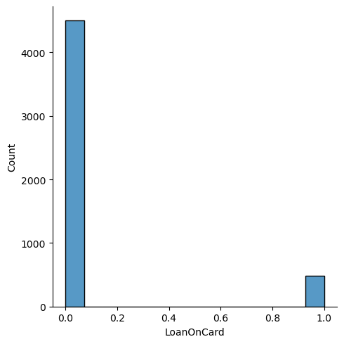

```python
import pandas as pd
import matplotlib.pyplot as plt
import seaborn as sb

print(dfr['LoanOnCard'].value_counts())
sb.displot(dfr, x="LoanOnCard")
plt.show()
```

*The plot shows that 4500 out of 5000 people have no loan on card. Only 480 out of remaining 500 people have loan on card and 20 people's status is unknown and has to be imputed*

**B. Check the percentage of missing values and impute if required. [1 Marks]**

```python
missing = dfr.isnull().sum()
percent_missing = dfr.isnull().sum() * 100 / len(dfr)
print(percent_missing)
```

```
ID                     0.0
Age                    0.0
CustomerSince          0.0
HighestSpend           0.0
ZipCode                0.0
HiddenScore            0.0
MonthlyAverageSpend    0.0
Level                  0.0
Mortgage               0.0
Security               0.0
FixedDepositAccount    0.0
InternetBanking        0.0
CreditCard             0.0
LoanOnCard             0.4
dtype: float64
```

**C. Check for unexpected values in each categorical variable and impute with best suitable value. [2 Marks]**

```python
dfr['LoanOnCard'].fillna(method='bfill', inplace=True)
dfr
```

|  | ID | Age | CustomerSince | HighestSpend | ZipCode | HiddenScore | MonthlyAverageSpend | Level | Mortgage | Security | FixedDepositAccount | InternetBanking | CreditCard | LoanOnCard |
| --- | --- | --- | --- | --- | --- | --- | --- | --- | --- | --- | --- | --- | --- | --- |
| 0 | 1 | 25 | 1 | 49 | 91107 | 4 | 1.6 | 1 | 0 | 1 | 0 | 0 | 0 | 1.0 |
| 1 | 2 | 45 | 19 | 34 | 90089 | 3 | 1.5 | 1 | 0 | 1 | 0 | 0 | 0 | 1.0 |
| 2 | 3 | 39 | 15 | 11 | 94720 | 1 | 1.0 | 1 | 0 | 0 | 0 | 0 | 0 | 1.0 |
| 3 | 4 | 35 | 9 | 100 | 94112 | 1 | 2.7 | 2 | 0 | 0 | 0 | 0 | 0 | 1.0 |
| 4 | 5 | 35 | 8 | 45 | 91330 | 4 | 1.0 | 2 | 0 | 0 | 0 | 0 | 1 | 1.0 |
| ... | ... | ... | ... | ... | ... | ... | ... | ... | ... | ... | ... | ... | ... | ... |
| 4995 | 4996 | 29 | 3 | 40 | 92697 | 1 | 1.9 | 3 | 0 | 0 | 0 | 1 | 0 | 0.0 |
| 4996 | 4997 | 30 | 4 | 15 | 92037 | 4 | 0.4 | 1 | 85 | 0 | 0 | 1 | 0 | 0.0 |
| 4997 | 4998 | 63 | 39 | 24 | 93023 | 2 | 0.3 | 3 | 0 | 0 | 0 | 0 | 0 | 0.0 |
| 4998 | 4999 | 65 | 40 | 49 | 90034 | 3 | 0.5 | 2 | 0 | 0 | 0 | 1 | 0 | 0.0 |
| 4999 | 5000 | 28 | 4 | 83 | 92612 | 3 | 0.8 | 1 | 0 | 0 | 0 | 1 | 1 | 0.0 |

5000 rows × 14 columns

```python
dfr.info()
```

```
<class 'pandas.core.frame.DataFrame'>
Int64Index: 5000 entries, 0 to 4999
Data columns (total 14 columns):
 #   Column               Non-Null Count  Dtype
---  ------               --------------  -----
 0   ID                   5000 non-null   int64
 1   Age                  5000 non-null   int64
 2   CustomerSince        5000 non-null   int64
 3   HighestSpend         5000 non-null   int64
 4   ZipCode              5000 non-null   int64
 5   HiddenScore          5000 non-null   object
 6   MonthlyAverageSpend  5000 non-null   float64
 7   Level                5000 non-null   object
 8   Mortgage             5000 non-null   int64
 9   Security             5000 non-null   object
 10  FixedDepositAccount  5000 non-null   object
 11  InternetBanking      5000 non-null   object
 12  CreditCard           5000 non-null   object
 13  LoanOnCard           5000 non-null   float64
dtypes: float64(2), int64(6), object(6)
memory usage: 715.0+ KB
```

# 3. Data Preparation and model building: [10 Marks]

**A. Split data into X and Y. [1 Marks]**

```python
dfr1=dfr.drop(['ID','ZipCode'], axis=1)
dfr1
```

|  | Age | CustomerSince | HighestSpend | HiddenScore | MonthlyAverageSpend | Level | Mortgage | Security | FixedDepositAccount | InternetBanking | CreditCard | LoanOnCard |
| --- | --- | --- | --- | --- | --- | --- | --- | --- | --- | --- | --- | --- |
| 0 | 25 | 1 | 49 | 4 | 1.6 | 1 | 0 | 1 | 0 | 0 | 0 | 1.0 |
| 1 | 45 | 19 | 34 | 3 | 1.5 | 1 | 0 | 1 | 0 | 0 | 0 | 1.0 |
| 2 | 39 | 15 | 11 | 1 | 1.0 | 1 | 0 | 0 | 0 | 0 | 0 | 1.0 |
| 3 | 35 | 9 | 100 | 1 | 2.7 | 2 | 0 | 0 | 0 | 0 | 0 | 1.0 |
| 4 | 35 | 8 | 45 | 4 | 1.0 | 2 | 0 | 0 | 0 | 0 | 1 | 1.0 |
| ... | ... | ... | ... | ... | ... | ... | ... | ... | ... | ... | ... | ... |
| 4995 | 29 | 3 | 40 | 1 | 1.9 | 3 | 0 | 0 | 0 | 1 | 0 | 0.0 |
| 4996 | 30 | 4 | 15 | 4 | 0.4 | 1 | 85 | 0 | 0 | 1 | 0 | 0.0 |
| 4997 | 63 | 39 | 24 | 2 | 0.3 | 3 | 0 | 0 | 0 | 0 | 0 | 0.0 |
| 4998 | 65 | 40 | 49 | 3 | 0.5 | 2 | 0 | 0 | 0 | 1 | 0 | 0.0 |
| 4999 | 28 | 4 | 83 | 3 | 0.8 | 1 | 0 | 0 | 0 | 1 | 1 | 0.0 |

5000 rows × 12 columns

```python
X = dfr1.iloc[:, 0:-1]
y = dfr1.iloc[:, -1]
```

```python
X
```

|  | Age | CustomerSince | HighestSpend | HiddenScore | MonthlyAverageSpend | Level | Mortgage | Security | FixedDepositAccount | InternetBanking | CreditCard |
| --- | --- | --- | --- | --- | --- | --- | --- | --- | --- | --- | --- |
| 0 | 25 | 1 | 49 | 4 | 1.6 | 1 | 0 | 1 | 0 | 0 | 0 |
| 1 | 45 | 19 | 34 | 3 | 1.5 | 1 | 0 | 1 | 0 | 0 | 0 |
| 2 | 39 | 15 | 11 | 1 | 1.0 | 1 | 0 | 0 | 0 | 0 | 0 |
| 3 | 35 | 9 | 100 | 1 | 2.7 | 2 | 0 | 0 | 0 | 0 | 0 |
| 4 | 35 | 8 | 45 | 4 | 1.0 | 2 | 0 | 0 | 0 | 0 | 1 |
| ... | ... | ... | ... | ... | ... | ... | ... | ... | ... | ... | ... |
| 4995 | 29 | 3 | 40 | 1 | 1.9 | 3 | 0 | 0 | 0 | 1 | 0 |
| 4996 | 30 | 4 | 15 | 4 | 0.4 | 1 | 85 | 0 | 0 | 1 | 0 |
| 4997 | 63 | 39 | 24 | 2 | 0.3 | 3 | 0 | 0 | 0 | 0 | 0 |
| 4998 | 65 | 40 | 49 | 3 | 0.5 | 2 | 0 | 0 | 0 | 1 | 0 |
| 4999 | 28 | 4 | 83 | 3 | 0.8 | 1 | 0 | 0 | 0 | 1 | 1 |

5000 rows × 11 columns

```python
y
```

```
0       1.0
1       1.0
2       1.0
3       1.0
4       1.0
       ...
4995    0.0
4996    0.0
4997    0.0
4998    0.0
4999    0.0
Name: LoanOnCard, Length: 5000, dtype: float64
```

```python
from sklearn.model_selection import train_test_split
x_train, x_test, y_train, y_test= train_test_split(X, y, test_size= 0.25, random_state=0)
#print('x_train:',x_train,'x_test:' x_test, 'y_train:',y_train, 'y_test:',y_test)
x_train
```

|  | Age | CustomerSince | HighestSpend | HiddenScore | MonthlyAverageSpend | Level | Mortgage | Security | FixedDepositAccount | InternetBanking | CreditCard |
| --- | --- | --- | --- | --- | --- | --- | --- | --- | --- | --- | --- |
| 4154 | 51 | 25 | 163 | 2 | 1.3 | 3 | 0 | 0 | 0 | 1 | 0 |
| 4820 | 42 | 17 | 44 | 1 | 0.3 | 3 | 0 | 1 | 1 | 1 | 1 |
| 1202 | 35 | 11 | 24 | 4 | 0.4 | 2 | 0 | 0 | 0 | 0 | 0 |
| 3759 | 31 | 4 | 29 | 4 | 1.5 | 2 | 121 | 0 | 0 | 1 | 1 |
| 622 | 41 | 17 | 92 | 2 | 1.9 | 1 | 131 | 0 | 0 | 1 | 0 |
| ... | ... | ... | ... | ... | ... | ... | ... | ... | ... | ... | ... |
| 4931 | 57 | 27 | 55 | 1 | 1.4 | 3 | 0 | 0 | 0 | 1 | 0 |
| 3264 | 67 | 41 | 114 | 4 | 2.4 | 3 | 0 | 0 | 0 | 1 | 0 |
| 1653 | 26 | 1 | 24 | 2 | 0.9 | 3 | 123 | 0 | 0 | 0 | 1 |
| 2607 | 57 | 33 | 49 | 4 | 1.5 | 1 | 214 | 1 | 1 | 1 | 1 |
| 2732 | 33 | 9 | 38 | 1 | 2.1 | 3 | 133 | 0 | 0 | 0 | 0 |

3750 rows × 11 columns

**C. Train a Supervised Learning Classification base model - Logistic Regression. [2 Marks]**

```python
x_test
```

|  | Age | CustomerSince | HighestSpend | HiddenScore | MonthlyAverageSpend | Level | Mortgage | Security | FixedDepositAccount | InternetBanking | CreditCard |
| --- | --- | --- | --- | --- | --- | --- | --- | --- | --- | --- | --- |
| 398 | 54 | 30 | 23 | 2 | 0.4 | 1 | 0 | 0 | 0 | 0 | 0 |
| 3833 | 33 | 9 | 83 | 1 | 0.1 | 1 | 0 | 0 | 0 | 1 | 0 |
| 4836 | 54 | 24 | 72 | 3 | 1.4 | 3 | 218 | 0 | 0 | 0 | 1 |
| 4572 | 32 | 7 | 81 | 4 | 1.8 | 3 | 0 | 0 | 0 | 1 | 0 |
| 636 | 40 | 16 | 120 | 2 | 6.1 | 1 | 196 | 0 | 0 | 1 | 0 |
| ... | ... | ... | ... | ... | ... | ... | ... | ... | ... | ... | ... |
| 465 | 66 | 42 | 35 | 1 | 1.9 | 2 | 172 | 0 | 0 | 1 | 0 |
| 2670 | 59 | 33 | 142 | 2 | 2.7 | 1 | 0 | 0 | 0 | 0 | 0 |
| 37 | 51 | 25 | 71 | 1 | 1.4 | 3 | 198 | 0 | 0 | 0 | 0 |
| 3081 | 36 | 10 | 78 | 2 | 4.5 | 3 | 204 | 0 | 0 | 1 | 1 |
| 2287 | 30 | 6 | 29 | 1 | 0.2 | 3 | 90 | 0 | 0 | 1 | 0 |

1250 rows × 11 columns

```python
y_test
```

```
398     0.0
3833    0.0
4836    0.0
4572    0.0
636     0.0
       ...
465     0.0
2670    0.0
37      0.0
3081    0.0
2287    0.0
Name: LoanOnCard, Length: 1250, dtype: float64
```

```python
y_train
```

```
4154    1.0
4820    0.0
1202    0.0
3759    0.0
622     0.0
       ...
4931    0.0
3264    0.0
1653    0.0
2607    0.0
2732    0.0
Name: LoanOnCard, Length: 3750, dtype: float64
```

```python
from sklearn.linear_model import LogisticRegression
logreg = LogisticRegression(solver = 'liblinear', multi_class= 'auto')
logreg.fit(x_train, y_train)
lr_score = logreg.score(x_test, y_test)
print(f"Score : {lr_score}")
```

```
Score : 0.9544
```

```python
pred = logreg.predict(x_test)
```

```python
import numpy as np
def rightly_identified(actual, predictions):
    a = pd.DataFrame()  # empty dataframe

    for i in np.sort(actual.unique()):
        try:  # because we get a key error if we use value_counts()[i] when the given class i does not exist in the value_count() array
            a.loc[i,'total_instances'] = len(actual[actual == i]) # value count of a given class i
            a.loc[i, 'identified_right'] = pd.Series(predictions[actual == i]).value_counts()[i] # number of instances where a given class i was identified correctly
            a.loc[i, '%'] = round(100*pd.Series(predictions[actual == i]).value_counts()[i]/len(actual[actual == i]), 1)  # percentage of predictions that were correct for a given class
        except:  # if the key error discussed above occurs, assign the percentage = 0
            a.loc[i, '%'] = 0.0
    return a
```

```python
pred_vs_actual_lr = rightly_identified(y_test, pred)
pred_vs_actual_lr
```

|  | total_instances | identified_right | % |
| --- | --- | --- | --- |
| 0.0 | 1139.0 | 1129.0 | 99.1 |
| 1.0 | 111.0 | 64.0 | 57.7 |

```python
def con_matrix(actual, predictions):
    from sklearn.metrics import confusion_matrix

    matrix = pd.DataFrame(confusion_matrix(actual, predictions), columns = np.unique(actual), index = np.unique(actual))
    # confusion_matrix() returns the confusion matrix. Wrapping this matrix in a dataframe with appropriate column names and index
    matrix.loc[:,'total_count_actual_class'] = matrix.sum(axis = 1)  # sum accross the columns
    matrix.loc['total_count_predicted'] = matrix.sum(axis = 0)  # row sum
    return matrix
```

```python
con_matrix(y_test, pred)
```

|  | 0.0 | 1.0 | total_count_actual_class |
| --- | --- | --- | --- |
| 0.0 | 1129 | 10 | 1139 |
| 1.0 | 47 | 64 | 111 |
| total_count_predicted | 1176 | 74 | 1250 |

```python
conmat=[[1129, 10],
        [47, 64]]
conmat
```

```
[[1129, 10], [47, 64]]
```

```python
from sklearn.metrics import accuracy_score
from sklearn.metrics import recall_score
from sklearn.metrics import precision_score
from sklearn.metrics import classification_report, confusion_matrix
print(classification_report(y_test, pred))
```

```
              precision    recall  f1-score   support

         0.0       0.96      0.99      0.98      1139
         1.0       0.86      0.58      0.69       111

    accuracy                           0.95      1250
   macro avg       0.91      0.78      0.83      1250
weighted avg       0.95      0.95      0.95      1250
```

*The accuracy of the model is high of 95% but the recall of the model is very less of 78%. It proves that the model is more biased. So, it proves that this is not the best model.

**E. Balance the data using the right balancing technique. [2 Marks]**

```python
pip install imblearn
```

```python
print("Before OverSampling, counts of label '1': {}".format(sum(y_train == 1)))
print("Before OverSampling, counts of label '0': {} \n".format(sum(y_train == 0)))

# import SMOTE module from imblearn library
# pip install imblearn (if you don't have imblearn in your system)
from imblearn.over_sampling import SMOTE
oversample = SMOTE()
X, y = oversample.fit_resample(X, y)
y
```

```
Before OverSampling, counts of label '1': 389
Before OverSampling, counts of label '0': 3361
```

```
0       1.0
1       1.0
2       1.0
3       1.0
4       1.0
       ...
8995    1.0
8996    1.0
8997    1.0
8998    1.0
8999    1.0
Name: LoanOnCard, Length: 9000, dtype: float64
```

```python
sm = SMOTE(random_state = 0)
x_train_res, y_train_res = sm.fit_resample(x_train, y_train.ravel())

print('After OverSampling, the shape of train_X: {}'.format(x_train_res.shape))
print('After OverSampling, the shape of train_y: {} \n'.format(y_train_res.shape))

print("After OverSampling, counts of label '1': {}".format(sum(y_train_res == 1)))
print("After OverSampling, counts of label '0': {}".format(sum(y_train_res == 0)))
```

```
After OverSampling, the shape of train_X: (6722, 11)
After OverSampling, the shape of train_y: (6722,)

After OverSampling, counts of label '1': 3361
After OverSampling, counts of label '0': 3361
```

**F. Again train the same previous model on balanced data. [1 Marks]**

```python
from sklearn.model_selection import train_test_split
x_train, x_test, y_train, y_test= train_test_split(X, y, test_size= 0.25, random_state=0)
x_train
```

|  | Age | CustomerSince | HighestSpend | HiddenScore | MonthlyAverageSpend | Level | Mortgage | Security | FixedDepositAccount | InternetBanking | CreditCard |
| --- | --- | --- | --- | --- | --- | --- | --- | --- | --- | --- | --- |
| 5600 | 32 | 8 | 191 | 1.316884 | 4.673246 | 2.683116 | 0 | 0.0 | 0.683116 | 1.0 | 0.683116 |
| 6548 | 56 | 30 | 114 | 3.939322 | 5.005832 | 1.0 | 0 | 1.0 | 1.0 | 0.939322 | 0.0 |
| 3981 | 64 | 39 | 22 | 3.0 | 0.500000 | 1.0 | 0 | 1.0 | 1.0 | 1.0 | 1.0 |
| 3223 | 43 | 18 | 29 | 1.0 | 0.500000 | 3.0 | 0 | 0.0 | 0.0 | 1.0 | 0.0 |
| 5707 | 45 | 20 | 112 | 2.488699 | 3.764691 | 1.75565 | 0 | 0.0 | 0.0 | 0.0 | 0.0 |
| ... | ... | ... | ... | ... | ... | ... | ... | ... | ... | ... | ... |
| 4373 | 30 | 6 | 139 | 1.0 | 4.300000 | 1.0 | 0 | 0.0 | 0.0 | 1.0 | 0.0 |
| 7891 | 53 | 27 | 139 | 2.412715 | 6.017457 | 2.587285 | 299 | 0.0 | 0.587285 | 0.587285 | 0.587285 |
| 4859 | 34 | 8 | 165 | 1.0 | 7.000000 | 3.0 | 541 | 0.0 | 0.0 | 0.0 | 0.0 |
| 3264 | 67 | 41 | 114 | 4.0 | 2.400000 | 3.0 | 0 | 0.0 | 0.0 | 1.0 | 0.0 |
| 2732 | 33 | 9 | 38 | 1.0 | 2.100000 | 3.0 | 133 | 0.0 | 0.0 | 0.0 | 0.0 |

6750 rows × 11 columns

```python
y_train
```

```
5600    1.0
6548    1.0
3981    0.0
3223    0.0
5707    1.0
       ...
4373    0.0
7891    1.0
4859    1.0
3264    0.0
2732    0.0
Name: LoanOnCard, Length: 6750, dtype: float64
```

```python
x_test
```

|  | Age | CustomerSince | HighestSpend | HiddenScore | MonthlyAverageSpend | Level | Mortgage | Security | FixedDepositAccount | InternetBanking | CreditCard |
| --- | --- | --- | --- | --- | --- | --- | --- | --- | --- | --- | --- |
| 4424 | 35 | 10 | 54 | 1.0 | 2.500000 | 3.0 | 0 | 0.0 | 0.0 | 0.0 | 1.0 |
| 1726 | 59 | 33 | 71 | 2.0 | 2.300000 | 3.0 | 150 | 0.0 | 0.0 | 1.0 | 1.0 |
| 7895 | 45 | 18 | 196 | 2.366246 | 8.795867 | 3.0 | 0 | 0.0 | 0.0 | 0.0 | 0.0 |
| 7586 | 34 | 8 | 137 | 1.517224 | 4.224131 | 2.655184 | 102 | 0.0 | 0.827592 | 0.827592 | 0.827592 |
| 1986 | 42 | 17 | 114 | 2.0 | 0.400000 | 1.0 | 0 | 0.0 | 0.0 | 0.0 | 0.0 |
| ... | ... | ... | ... | ... | ... | ... | ... | ... | ... | ... | ... |
| 7677 | 44 | 20 | 132 | 3.730688 | 5.628183 | 3.0 | 0 | 0.0 | 0.910229 | 1.0 | 0.910229 |
| 1687 | 63 | 39 | 83 | 3.0 | 2.000000 | 3.0 | 0 | 0.0 | 0.0 | 1.0 | 1.0 |
| 2078 | 35 | 11 | 21 | 2.0 | 1.000000 | 2.0 | 0 | 0.0 | 0.0 | 0.0 | 0.0 |
| 4902 | 33 | 8 | 58 | 2.0 | 2.500000 | 1.0 | 0 | 0.0 | 0.0 | 1.0 | 0.0 |
| 5768 | 31 | 5 | 127 | 3.067394 | 5.749711 | 2.932606 | 317 | 0.932606 | 0.932606 | 0.0 | 1.0 |

2250 rows × 11 columns

```python
from sklearn.linear_model import LogisticRegression
logreg = LogisticRegression(solver = 'liblinear', multi_class= 'auto')
logreg.fit(x_train, y_train)
lr_score = logreg.score(x_test, y_test)
print(f"Score : {lr_score}")
```

```
Score : 0.892
```

**G. Print evaluation metrics and clearly share differences observed. [2 Marks]**

```python
pred = logreg.predict(x_test)
print(classification_report(y_test, pred))
```

```
              precision    recall  f1-score   support

         0.0       0.90      0.88      0.89      1122
         1.0       0.88      0.91      0.89      1128

    accuracy                           0.89      2250
   macro avg       0.89      0.89      0.89      2250
weighted avg       0.89      0.89      0.89      2250
```

# 4. Performance Improvement: [10 Marks]

**A. Train a base model each for SVM, KNN. [4 Marks]**

**SVM MODEL**

```python
from sklearn.svm import SVC

# Building a Support Vector Machine on train data
svc_model = SVC(C= .1, kernel='linear', gamma= 1)
svc_model.fit(x_train, y_train)

prediction = svc_model .predict(x_test)
```

```python
# check the accuracy on the training set
print(svc_model.score(x_train, y_train))
print(svc_model.score(x_test, y_test))
```

```
0.8965925925925926
0.8906666666666667
```

```python
print("SVM Evaluation metrics")
print(classification_report(y_test, prediction))
```

```
SVM Evaluation metrics
              precision    recall  f1-score   support

         0.0       0.90      0.88      0.89      1122
         1.0       0.88      0.91      0.89      1128

    accuracy                           0.89      2250
   macro avg       0.89      0.89      0.89      2250
weighted avg       0.89      0.89      0.89      2250
```

**KNN MODEL**

```python
from sklearn.neighbors import KNeighborsClassifier
from sklearn.metrics import accuracy_score
from sklearn.metrics import recall_score

# instantiate learning model (k = 3)
knn = KNeighborsClassifier(n_neighbors = 3)

# fitting the model
knn.fit(x_train, y_train)

# predict the response
y_pred = knn.predict(x_test)

# evaluate accuracy
print(accuracy_score(y_test, y_pred))
```

```
0.9102222222222223
```

```python
print("KNN Evaluation metrics")
print(classification_report(y_test, y_pred))
```

```
KNN Evaluation metrics
              precision    recall  f1-score   support

         0.0       0.96      0.85      0.90      1122
         1.0       0.87      0.97      0.92      1128

    accuracy                           0.91      2250
   macro avg       0.92      0.91      0.91      2250
weighted avg       0.92      0.91      0.91      2250
```

**B. Tune parameters for each of the models wherever required and finalize a model. [3 Marks]**

**SVM MODEL-AFTER TUNING HYPERPARAMETERS**

```python
from sklearn.model_selection import GridSearchCV

# defining parameter range
param_grid = {'C': [0.1, 1, 10, 100, 1000],
              'gamma': [1, 0.1, 0.01, 0.001, 0.0001],
              'kernel': ['rbf']}

grid = GridSearchCV(SVC(), param_grid, refit = True, verbose = 3)

# fitting the model for grid search
grid.fit(x_train, y_train)
# print best parameter after tuning
print(grid.best_params_)

# print how our model looks after hyper-parameter tuning
print(grid.best_estimator_)
```

```
Fitting 5 folds for each of 25 candidates, totalling 125 fits
[CV 1/5] END ........C=0.1, gamma=1, kernel=rbf;, score=0.500 total time=   3.0s
[CV 2/5] END ........C=0.1, gamma=1, kernel=rbf;, score=0.500 total time=   3.5s
[CV 3/5] END ........C=0.1, gamma=1, kernel=rbf;, score=0.501 total time=   3.2s
[CV 4/5] END ........C=0.1, gamma=1, kernel=rbf;, score=0.501 total time=   3.5s
[CV 5/5] END ........C=0.1, gamma=1, kernel=rbf;, score=0.501 total time=   3.6s
[CV 1/5] END ......C=0.1, gamma=0.1, kernel=rbf;, score=0.757 total time=   3.0s
[CV 2/5] END ......C=0.1, gamma=0.1, kernel=rbf;, score=0.750 total time=   3.6s
[CV 3/5] END ......C=0.1, gamma=0.1, kernel=rbf;, score=0.781 total time=   3.1s
[CV 4/5] END ......C=0.1, gamma=0.1, kernel=rbf;, score=0.760 total time=   3.0s
[CV 5/5] END ......C=0.1, gamma=0.1, kernel=rbf;, score=0.781 total time=   3.1s
[CV 1/5] END .....C=0.1, gamma=0.01, kernel=rbf;, score=0.875 total time=   1.7s
[CV 2/5] END .....C=0.1, gamma=0.01, kernel=rbf;, score=0.879 total time=   2.1s
[CV 3/5] END .....C=0.1, gamma=0.01, kernel=rbf;, score=0.881 total time=   2.6s
[CV 4/5] END .....C=0.1, gamma=0.01, kernel=rbf;, score=0.845 total time=   1.9s
[CV 5/5] END .....C=0.1, gamma=0.01, kernel=rbf;, score=0.859 total time=   1.6s
[CV 1/5] END ....C=0.1, gamma=0.001, kernel=rbf;, score=0.866 total time=   0.9s
[CV 2/5] END ....C=0.1, gamma=0.001, kernel=rbf;, score=0.873 total time=   0.9s
[CV 3/5] END ....C=0.1, gamma=0.001, kernel=rbf;, score=0.877 total time=   0.9s
[CV 4/5] END ....C=0.1, gamma=0.001, kernel=rbf;, score=0.850 total time=   0.9s
[CV 5/5] END ....C=0.1, gamma=0.001, kernel=rbf;, score=0.865 total time=   0.9s
[CV 1/5] END ...C=0.1, gamma=0.0001, kernel=rbf;, score=0.859 total time=   0.8s
[CV 2/5] END ...C=0.1, gamma=0.0001, kernel=rbf;, score=0.870 total time=   0.9s
[CV 3/5] END ...C=0.1, gamma=0.0001, kernel=rbf;, score=0.876 total time=   0.9s
[CV 4/5] END ...C=0.1, gamma=0.0001, kernel=rbf;, score=0.849 total time=   1.0s
[CV 5/5] END ...C=0.1, gamma=0.0001, kernel=rbf;, score=0.861 total time=   1.3s
[CV 1/5] END ..........C=1, gamma=1, kernel=rbf;, score=0.778 total time=   3.4s
[CV 2/5] END ..........C=1, gamma=1, kernel=rbf;, score=0.770 total time=   3.4s
[CV 3/5] END ..........C=1, gamma=1, kernel=rbf;, score=0.785 total time=   3.5s
[CV 4/5] END ..........C=1, gamma=1, kernel=rbf;, score=0.773 total time=   3.4s
[CV 5/5] END ..........C=1, gamma=1, kernel=rbf;, score=0.794 total time=   5.2s
[CV 1/5] END ........C=1, gamma=0.1, kernel=rbf;, score=0.904 total time=   3.4s
[CV 2/5] END ........C=1, gamma=0.1, kernel=rbf;, score=0.909 total time=   3.1s
[CV 3/5] END ........C=1, gamma=0.1, kernel=rbf;, score=0.898 total time=   3.2s
[CV 4/5] END ........C=1, gamma=0.1, kernel=rbf;, score=0.896 total time=   3.8s
[CV 5/5] END ........C=1, gamma=0.1, kernel=rbf;, score=0.910 total time=   3.2s
[CV 1/5] END .......C=1, gamma=0.01, kernel=rbf;, score=0.903 total time=   1.2s
[CV 2/5] END .......C=1, gamma=0.01, kernel=rbf;, score=0.914 total time=   1.4s
[CV 3/5] END .......C=1, gamma=0.01, kernel=rbf;, score=0.915 total time=   1.3s
[CV 4/5] END .......C=1, gamma=0.01, kernel=rbf;, score=0.896 total time=   1.2s
```

[output cut: 73 more lines]

```
[CV 3/5] END ....C=1000, gamma=0.01, kernel=rbf;, score=0.961 total time=   1.3s
[CV 4/5] END ....C=1000, gamma=0.01, kernel=rbf;, score=0.956 total time=   1.3s
[CV 5/5] END ....C=1000, gamma=0.01, kernel=rbf;, score=0.954 total time=   1.4s
[CV 1/5] END ...C=1000, gamma=0.001, kernel=rbf;, score=0.964 total time=   2.1s
[CV 2/5] END ...C=1000, gamma=0.001, kernel=rbf;, score=0.955 total time=   1.4s
[CV 3/5] END ...C=1000, gamma=0.001, kernel=rbf;, score=0.969 total time=   1.5s
[CV 4/5] END ...C=1000, gamma=0.001, kernel=rbf;, score=0.953 total time=   1.3s
[CV 5/5] END ...C=1000, gamma=0.001, kernel=rbf;, score=0.961 total time=   1.2s
[CV 1/5] END ..C=1000, gamma=0.0001, kernel=rbf;, score=0.957 total time=   1.3s
[CV 2/5] END ..C=1000, gamma=0.0001, kernel=rbf;, score=0.959 total time=   1.3s
[CV 3/5] END ..C=1000, gamma=0.0001, kernel=rbf;, score=0.950 total time=   1.4s
[CV 4/5] END ..C=1000, gamma=0.0001, kernel=rbf;, score=0.937 total time=   1.3s
[CV 5/5] END ..C=1000, gamma=0.0001, kernel=rbf;, score=0.949 total time=   1.4s
{'C': 1000, 'gamma': 0.001, 'kernel': 'rbf'}
SVC(C=1000, gamma=0.001)
```

```python
grid_predictions = grid.predict(x_test)

# print classification report
print(classification_report(y_test, grid_predictions))
```

```
              precision    recall  f1-score   support

         0.0       0.98      0.96      0.97      1122
         1.0       0.96      0.98      0.97      1128

    accuracy                           0.97      2250
   macro avg       0.97      0.97      0.97      2250
weighted avg       0.97      0.97      0.97      2250
```

**KNN MODEL-AFTER TUNING HYPERPARAMETERS**

```python
# creating odd list of K for KNN
myList = list(range(1,20))
ac_scores=[]
# subsetting just the odd ones
neighbors = list(filter(lambda x: x % 2 != 0, myList))
for k in neighbors:
    knn = KNeighborsClassifier(n_neighbors=k)
    knn.fit(x_train, y_train)
    # predict the response
    y_pred = knn.predict(x_test)
    # evaluate accuracy
    scores = accuracy_score(y_test, y_pred)
    ac_scores.append(scores)
# changing to misclassification error
MSE = [1 - x for x in ac_scores]

# determining best k
optimal_k = neighbors[MSE.index(min(MSE))]
print("The optimal number of neighbors is %d" % optimal_k)
```

```
The optimal number of neighbors is 1
```

```python
knn = KNeighborsClassifier(n_neighbors = 1)

# fitting the model
knn.fit(x_train, y_train)

# predict the response
y_pred = knn.predict(x_test)

# evaluate accuracy
print(accuracy_score(y_test, y_pred))
```

```
0.9248888888888889
```

**C. Print evaluation metrics for final model. [1 Marks]**

**SVM TUNED MODEL EVALUATION METRICS**

```python
print(classification_report(y_test, grid_predictions))
```

```
              precision    recall  f1-score   support

         0.0       0.98      0.96      0.97      1122
         1.0       0.96      0.98      0.97      1128

    accuracy                           0.97      2250
   macro avg       0.97      0.97      0.97      2250
weighted avg       0.97      0.97      0.97      2250
```

**KNN TUNED MODEL EVALUATION METRICS**

```python
print(classification_report(y_test, y_pred))
```

```
              precision    recall  f1-score   support

         0.0       0.97      0.88      0.92      1122
         1.0       0.89      0.97      0.93      1128

    accuracy                           0.92      2250
   macro avg       0.93      0.92      0.92      2250
weighted avg       0.93      0.92      0.92      2250
```

**D. Share improvement achieved from base model to final model. [2 Marks]**

*The optimized and tuned model for both techniques show better evaluation metrics compared to untuned model. Also SVM model gives better eveluation metrics compared to KNN. So SVM tuned for C=1000, gamma=0.001 is the best model*